# EDA_Haberman

```python
import warnings
warnings.filterwarnings("ignore")
import matplotlib.pyplot as plt
import seaborn as sns
import numpy as np
import pandas as pd
```

```python
data_df = pd.read_csv('haberman.csv')
```

1. Age of patient at time of operation (numerical & continous)
2. Patient's year of operation (year - 1900, numerical & continous)
3. Number of positive axillary nodes detected (numerical & ordinal)
4. Survival status (dependent, nominal, categorical and target variable)

   ```
     #1 = the patient survived > 5 years after operation
     #2 = the patient died within 5 year
   ```

Objective: Given the Age, year of operation and no.of positive axillary nodes detected, We need to predict the survival status.

```python
print(data_df.shape)
data_df.head()
```

```
(306, 4)
```

|  | age | year | nodes | status |
| --- | --- | --- | --- | --- |
| 0 | 30 | 64 | 1 | 1 |
| 1 | 30 | 62 | 3 | 1 |
| 2 | 30 | 65 | 0 | 1 |
| 3 | 31 | 59 | 2 | 1 |
| 4 | 31 | 65 | 4 | 1 |

Observation: The data set has 306 data points and 4 variables in total, 3 are independent and 1 is depenedent

```python
data_df['status'].value_counts()   # target variable
```

```
1    225
2     81
Name: status, dtype: int64
```

Observation: The data is imbalanced with ratio of 2.7777. The people survived are 2.777 times more than people died. The chance of surivial = 73.5%

```python
data_df.isnull().sum()   # no null values in any of the columns
```

```
age       0
year      0
nodes     0
status    0
dtype: int64
```

```python
data_df.describe()   # get stats of data
```

|  | age | year | nodes | status |
| --- | --- | --- | --- | --- |
| count | 306.000000 | 306.000000 | 306.000000 | 306.000000 |
| mean | 52.457516 | 62.852941 | 4.026144 | 1.264706 |
| std | 10.803452 | 3.249405 | 7.189654 | 0.441899 |
| min | 30.000000 | 58.000000 | 0.000000 | 1.000000 |
| 25% | 44.000000 | 60.000000 | 0.000000 | 1.000000 |
| 50% | 52.000000 | 63.000000 | 1.000000 | 1.000000 |
| 75% | 60.750000 | 65.750000 | 4.000000 | 2.000000 |
| max | 83.000000 | 69.000000 | 52.000000 | 2.000000 |

Observations:

1. While highest no.of nodes is 52, 75% has nodes less than or equal to 4 and 25% has 0 nodes.
2. mean for nodes is 4 and median for the same is 1, this represents the data of nodes is skewed.
3. Other columns, age and year have almost equal mean and median represents that both columns are in normal distrubution.

```python
print(data_df.dtypes)
data_df = data_df.astype('int8')   # for memory optimization as maxvalue in dataframe is only 83.
data_df.dtypes
```

```
age       int64
year      int64
nodes     int64
status    int64
dtype: object
```

```
age       int8
year      int8
nodes     int8
status    int8
dtype: object
```

### Univariate Analysis

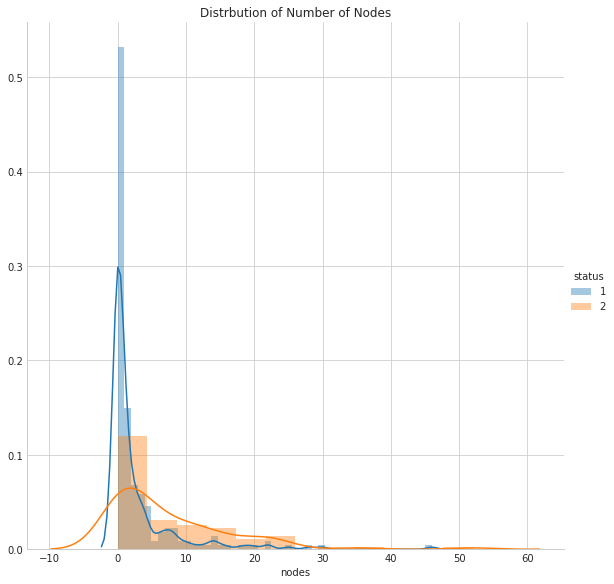

```python
sns.FacetGrid(data_df, hue="status", size=8) \
   .map(sns.distplot, "nodes") \
   .add_legend();
plt.title('Distrbution of Number of Nodes')
plt.show();
```

1.In case of 0 nodes, the probability to survive more than 5 years in more.

2.For nodes > 1, the probability of dying with in 5 years is more.

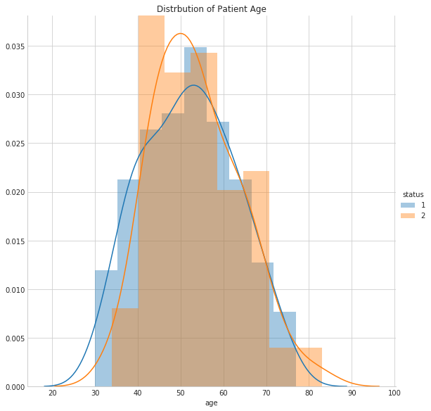

```python
sns.FacetGrid(data_df, hue="status", size=8) \
   .map(sns.distplot, "age") \
   .add_legend();
plt.title('Distrbution of Patient Age')
plt.show();
```

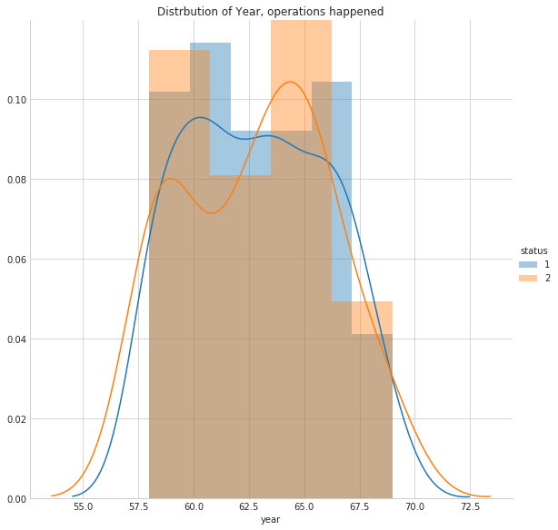

```python
sns.FacetGrid(data_df, hue="status", size=8) \
   .map(sns.distplot, "year") \
   .add_legend();
plt.title('Distrbution of Year, operations happened')
plt.show();
```

1. With almost similar distributions, year seams to be less important variable.
2. Deaths for year 63 to 66 and 58 to 59 are more than the survivals

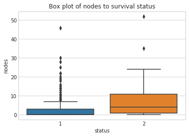

```python
sns.boxplot(x='status', y='nodes', data=data_df)
plt.title('Box plot of nodes to survival status')
plt.show()
```

Observations: There seem to be more outliers where no.of nodes being high and survived. Nodes > 30 are very rare.

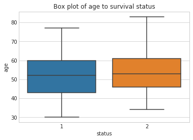

```python
sns.boxplot(x='status', y='age', data=data_df)
plt.title('Box plot of age to survival status')
plt.show()
```

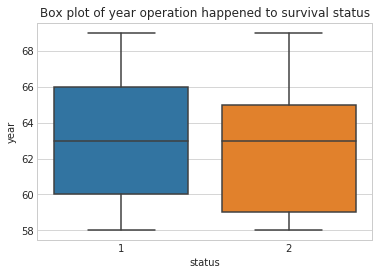

```python
sns.boxplot(x='status', y='year', data=data_df)
plt.title('Box plot of year operation happened to survival status')
plt.show()
```

Observations: There is lot of overlapping b/w both survived and not survived cases when compared using age and year.With only these features, status cannot be predicted accurately, making the no.of nodes most important feature.

#### PDFs and CFDs

```python
status1 = data_df[ data_df['status'] == 1]
status2 = data_df[ data_df['status'] == 2]
```

```python
status1.describe()
```

|  | age | year | nodes | status |
| --- | --- | --- | --- | --- |
| count | 225.000000 | 225.000000 | 225.000000 | 225.0 |
| mean | 52.017778 | 62.862222 | 2.791111 | 1.0 |
| std | 11.012154 | 3.222915 | 5.870318 | 0.0 |
| min | 30.000000 | 58.000000 | 0.000000 | 1.0 |
| 25% | 43.000000 | 60.000000 | 0.000000 | 1.0 |
| 50% | 52.000000 | 63.000000 | 0.000000 | 1.0 |
| 75% | 60.000000 | 66.000000 | 3.000000 | 1.0 |
| max | 77.000000 | 69.000000 | 46.000000 | 1.0 |

```python
status2.describe()
```

|  | age | year | nodes | status |
| --- | --- | --- | --- | --- |
| count | 81.000000 | 81.000000 | 81.000000 | 81.0 |
| mean | 53.679012 | 62.827160 | 7.456790 | 2.0 |
| std | 10.167137 | 3.342118 | 9.185654 | 0.0 |
| min | 34.000000 | 58.000000 | 0.000000 | 2.0 |
| 25% | 46.000000 | 59.000000 | 1.000000 | 2.0 |
| 50% | 53.000000 | 63.000000 | 4.000000 | 2.0 |
| 75% | 61.000000 | 65.000000 | 11.000000 | 2.0 |
| max | 83.000000 | 69.000000 | 52.000000 | 2.0 |

Observations:

1. The measure of central tendancies didnt vary for the "year" variable for both cases.
2. There is slight change in median "age" of who survived and who is not.
3. The median of "no.of nodes" has seen significant change in case of who didnt survived when compared to who survived

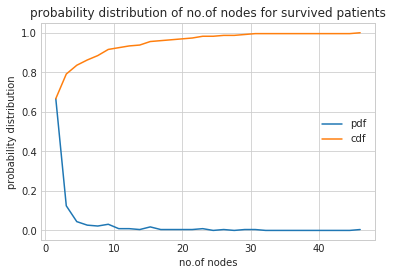

```python
# nodes are most important of all three

counts, bin_edges = np.histogram(status1['nodes'], bins=30,
                                 density = True)
pdf = counts/(sum(counts))
cdf = np.cumsum(pdf)
plt.plot(bin_edges[1:],pdf)
plt.plot(bin_edges[1:], cdf)

plt.legend(['pdf', 'cdf'])
plt.xlabel('no.of nodes')
plt.ylabel('probability distribution')
plt.title( 'probability distribution of no.of nodes for survived patients')
plt.show();
```

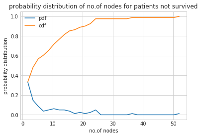

```python
#versicolor
counts, bin_edges = np.histogram(status2['nodes'], bins=30,
                                 density = True)
pdf = counts/(sum(counts))
cdf = np.cumsum(pdf)
plt.plot(bin_edges[1:],pdf)
plt.plot(bin_edges[1:], cdf)
plt.xlabel('no.of nodes')
plt.ylabel('probability distribution')
plt.title( 'probability distribution of no.of nodes for patients not survived')
plt.legend(['pdf', 'cdf'])
```

Observations: From the above two pdfs, The probability for surivival in more in case of nodes = 0 (1st bin) and in all remaining cases (nodes > 1) the probability of survival is less than or equal to non-survival.

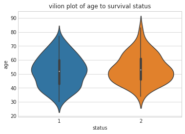

```python
sns.violinplot(x="status", y="age", data=data_df, size=6)
plt.title('vilion plot of age to survival status')
plt.show()
```

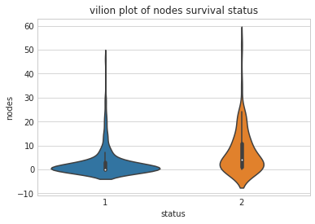

```python
sns.violinplot(x="status", y="nodes", data=data_df, size=6)
plt.title('vilion plot of nodes survival status')
plt.show()
```

1. The probability for status 1 is more for nodes = 0
2. The Probability for status 2 is more for nodes > 1

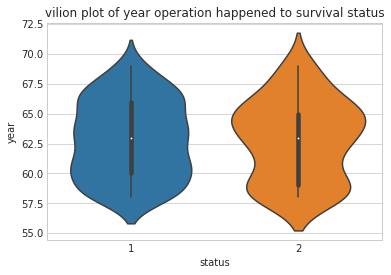

```python
sns.violinplot(x="status", y="year", data=data_df, size=6)
plt.title('vilion plot of year operation happened to survival status')
plt.show()
```

1. More non-survival cases happened in the year 65 and lowest in the year 61.

### BiVariate Analysis

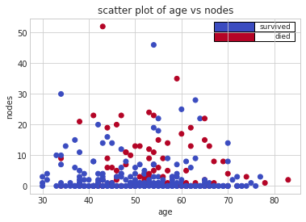

```python
cmap = plt.cm.get_cmap("coolwarm",2)
plt.scatter(x = data_df['age'], y = data_df['nodes'], c = data_df['status'], label = data_df['status'],
            cmap = cmap)
plt.xlabel('age')
plt.ylabel('nodes')
unique_classes = [1,2]
labels = ['survived', 'died']
plt.table(cellText=[[x] for x in labels], loc='best',
          colWidths=[0.15],rowColours=cmap(np.array(unique_classes)-1))
plt.title( 'scatter plot of age vs nodes')
plt.show()
```

Observations:

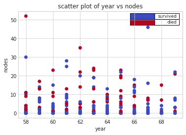

```python
plt.scatter(x = data_df['year'], y = data_df['nodes'], c = data_df['status'], cmap = 'coolwarm' )
plt.xlabel('year')
plt.ylabel('nodes')
unique_classes = [1,2]
labels = ['survived', 'died']
plt.table(cellText=[[x] for x in labels], loc='best',
          colWidths=[0.15],rowColours=cmap(np.array(unique_classes)-1))
plt.title( 'scatter plot of year vs nodes')
plt.show()
```

Observations: nodes and year are also not correlated

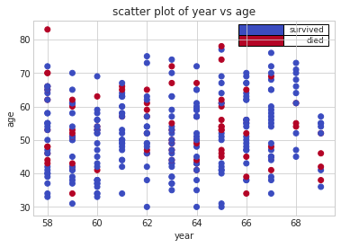

```python
plt.scatter(x = data_df['year'], y = data_df['age'], c = data_df['status'], cmap = 'coolwarm' )
plt.xlabel('year')
plt.ylabel('age')
unique_classes = [1,2]
labels = ['survived', 'died']
plt.table(cellText=[[x] for x in labels], loc='best',
          colWidths=[0.15],rowColours=cmap(np.array(unique_classes)-1))
plt.title( 'scatter plot of year vs age')
plt.show()
```

Observations: most no.of non-surivial operations happend in the years 58 - 60 & 65-66

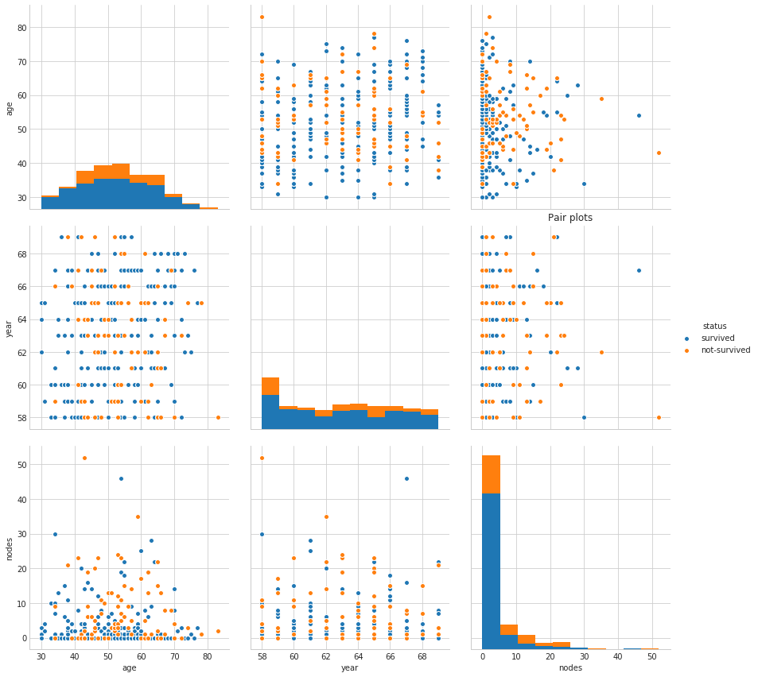

```python
pp_df = data_df.copy()
pp_df['status'] = pp_df['status'].replace({1:'survived', 2: 'not-survived'})
sns.pairplot(pp_df, hue = 'status', vars = ['age', 'year', 'nodes'], size=4)
plt.title("Pair plots")
plt.show()
```

Observations:

1. nodes is the most important feature of all three

### MultiVariate Analysis

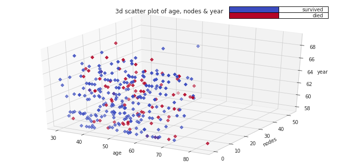

```python
from mpl_toolkits import mplot3d
fig = plt.figure(figsize = (12,6))
ax = plt.axes(projection='3d')
ax.scatter3D(data_df['age'], data_df['nodes'], data_df['year'], c = data_df['status'], cmap='coolwarm', marker='D')
ax.set_xlabel('age')
ax.set_ylabel('nodes')
ax.set_zlabel('year')
plt.title('3d scatter plot of age, nodes & year')
unique_classes = [1,2]
labels = ['survived', 'died']
plt.table(cellText=[[x] for x in labels], loc='best',
          colWidths=[0.15],rowColours=cmap(np.array(unique_classes)-1))
```

Observations: The data is not linearly separable, may be using decision trees could be better option.

Final Conclusions:

Feature Importance:

1. nodes is most important feature in this dataset, as who had Axil node >= 1 those are more likely to die.
2. Age is also somewhat important feature as patients who aged less than 45 are likely to survive inspite of having node >= 1 and people with Age > 40 and nodes > 10 are not likely to survive.

```python
# import plotly.plotly as py
# import plotly.graph_objs as go
```

```python
# trace = go.Scatter3d(x=data_df['age'].values,
#     y=data_df['nodes'].values,
#     z=data_df['year'].values,
#     mode='markers',
#     marker=dict(size=12,line=dict(color='rgba(217, 217, 217, 0.14)',width=0.5),
#     opacity=0.8))

# data = [trace]
# py.iplot(data)
```